# ZUM Projekt

## Opis projektu

**Temat projektu:** Nienadzorowana detekcja anomalii za lasu izolacyjnego. Funkcje do tworzenia modelu i predykcji. Porównanie z nadzorowaną detekcją anomalii za pomocą dostępnych w R algorytmów klasyfikacji.

## Struktura katalogów w projekcie przedstawia się nastepująco:

- **data** - katalog przechowyjący dane wejściowy
- **info** - katalog przechowujący sprawozdanie projektu
- **src** - katalog przechowujący kod żrodłowy
- **isolation_forest.Rmd** - główny plik (notatnik) zawierajacy uruchomenie kodu oraz opis
- **isolation_forest.html** - plik wynikowy generowany na podstawie isolation_forest.Rmd

## Wymagane biblioteki na potrzeby projektu

```r
library(ggplot2)
library(solitude)
library(R.matlab)
library(class)
library(caret)
library(e1071)
library(randomForest)
library(CORElearn)
library(Rlof)
library(dbscan)
library(grid)
library(gridExtra)
library(ROCR)

source("src/IsolationForest.R")
```

### Przygotowanie danych

- **load_mat_data** - wczytuje dane z pliku o formacie .mat do tabeli
- **load_data** - wczytuje dane z pliku do tabeli (data frame-u) w formacie innych niż *.mat
- **print_mat_data_info** - funkcja wypisująca informacja o plikach formatu *.mat.

### Wczytywanie danych

Dane wzięty ze strony [Outlier Detection DataSets (ODDS)](http://odds.cs.stonybrook.edu/) oraz [Kaggle](https://www.kaggle.com/)

1. Credit Card Fraud Detection (Kaggle) [link](https://www.kaggle.com/mlg-ulb/creditcardfraud)
2. Arrhythmia dataset (ODDS) [link](http://odds.cs.stonybrook.edu/arrhythmia-dataset/)
3. http (KDDCUP99) dataset (ODDS) [link](http://odds.cs.stonybrook.edu/http-kddcup99-dataset/)
4. [Temporary] kddcup.data_10_percent_corrected - Zbiór danych obejmuje szeroką gamę ???włamań??? symulowanych w wojskowym środowisku sieciowym. [link](http://kdd.ics.uci.edu/databases/kddcup99/kddcup99.html)

#### Wczytywanie danych z pliku arrhythmia.mat:

**Opis danych.** Dane składają się z dwóch tabel X i Y:

- X - to wielowymiarowe dane punktowe rozmiaru **N x M**, gdzie N - to liczba punkt, a M - to liczba cech.
- Y - to zbior etykiety o rozmiarze N (liczby punktów), oznaczajczy czy dany punkt jest wartością odstającą (1 = outliers, 0 = inliers)

#### Wczytywania danych z pliku http.mat:

**Opis danych.** Dane składają się z dwóch tabel X i Y:

- X - to wielowymiarowe dane punktowe rozmiaru **N x M**, gdzie N - to liczba punkt, a M - to liczba cech.
- Y - to zbior etykiety o rozmiarze N (liczby punktów), oznaczajczy czy dany punkt jest wartością odstającą (1 = outliers, 0 = inliers)

```r
http_data_df <- mat_to_df("data/http_save.mat")
```

```
[1] "Information for file: data/http_save.mat"
[1] "Ilosc danych N: 567498, Liczba parametrów M: 3, Liczba ouliers: 2211"
```

```r
head(http_data_df, 3)
```

|  | label | X1 | X2 | X3 |
| --- | --- | --- | --- | --- |
| 1 | 0 | -2.302585 | 5.371103 | 10.716107 |
| 2 | 0 | -2.302585 | 5.088213 | 8.418058 |
| 3 | 0 | -2.302585 | 5.464255 | 7.113224 |

#### Wczytywania danych z pliku creditcard.csv:

**Opis danych**:

Zbiór danych zawiera transakcje dokonane kartami kredytowymi we wrześniu 2013 r. przez europejskich posiadaczy kart. Ten zbiór danych przedstawia transakcje, które miały miejsce w ciągu dwóch dni, w których mamy **492 oszustw** z 284 807 transakcji.

Dane przedstawione za pomocą tabeli o rozmiarze **N x M** gdzie:

- N - ilość transakcyj
- M - liczba cech, których jest 31

Cechy:

1. Ze względu na to, że oryganalnych danych nie można udostępnić, ze względu zabiezpieczęnie danych użytkownika, to mama doczynienia z danymi, które są wynikem redukcji wymiarowości za pomocą PCA (angl. *Principal Component Analysis*).Te cechy w tabele przedstawione jako V1, V2, V3, … , V28.
2. Time - zawiera liczba sekund która upłynęła między każdą transakcją a pierwszą transakcją w zbiorze danych.
3. Amount - to kwota transakcji.
4. class - przejmuję wartość 1 gdy transakcja jest oszustwem (outliers) i 0 w przeciwnym przypadku.

```r
creditcard_data_df <- load_data("data/creditcard.csv")
```

```
[1] "Information for file credit_card.csv"
[1] "Ilosc danych N: 284807, Liczba parametrów M: 30, Liczba ouliers: 492"
```

```r
head(creditcard_data_df, 3)
```

|  | Time | V1 | V2 | V3 | V4 | V5 | V6 | V7 | V8 | V9 | V10 | V11 | V12 | V13 | V14 | V15 | V16 | V17 | V18 | V19 | V20 | V21 | V22 | V23 | V24 | V25 | V26 | V27 | V28 | … |
| --- | --- | --- | --- | --- | --- | --- | --- | --- | --- | --- | --- | --- | --- | --- | --- | --- | --- | --- | --- | --- | --- | --- | --- | --- | --- | --- | --- | --- | --- | --- |
| 2 | 0 | -1.3598071336738 | -0.0727811733098497 | 2.53634673796914 | 1.37815522427443 | -0.338320769942518 | 0.462387777762292 | 0.239598554061257 | 0.0986979012610507 | 0.363786969611213 | 0.0907941719789316 | -0.551599533260813 | -0.617800855762348 | -0.991389847235408 | -0.311169353699879 | 1.46817697209427 | -0.470400525259478 | 0.207971241929242 | 0.0257905801985591 | 0.403992960255733 | 0.251412098239705 | -0.018306777944153 | 0.277837575558899 | -0.110473910188767 | 0.0669280749146731 | 0.128539358273528 | -0.189114843888824 | 0.133558376740387 | -0.0210530534538215 | … |
| 3 | 0 | 1.19185711131486 | 0.26615071205963 | 0.16648011335321 | 0.448154078460911 | 0.0600176492822243 | -0.0823608088155687 | -0.0788029833323113 | 0.0851016549148104 | -0.255425128109186 | -0.166974414004614 | 1.61272666105479 | 1.06523531137287 | 0.48909501589608 | -0.143772296441519 | 0.635558093258208 | 0.463917041022171 | -0.114804663102346 | -0.183361270123994 | -0.145783041325259 | -0.0690831352230203 | -0.225775248033138 | -0.638671952771851 | 0.101288021253234 | -0.339846475529127 | 0.167170404418143 | 0.125894532368176 | -0.00898309914322813 | 0.0147241691924927 | … |
| 4 | 1 | -1.35835406159823 | -1.34016307473609 | 1.77320934263119 | 0.379779593034328 | -0.503198133318193 | 1.80049938079263 | 0.791460956450422 | 0.247675786588991 | -1.51465432260583 | 0.207642865216696 | 0.624501459424895 | 0.066083685268831 | 0.717292731410831 | -0.165945922763554 | 2.34586494901581 | -2.89008319444231 | 1.10996937869599 | -0.121359313195888 | -2.26185709530414 | 0.524979725224404 | 0.247998153469754 | 0.771679401917229 | 0.909412262347719 | -0.689280956490685 | -0.327641833735251 | -0.139096571514147 | -0.0553527940384261 | -0.0597518405929204 | … |

### Metryki do sprawdzenia wyników

- **prepare_train_data** - przygotowania zbiora danych z możliwości selekcji okreslonego procentu tych danych.
- **run_evaluation_metrics** - wyświetelenie macierz błędów (angl. *Confusion matrix*), Recall oraz Precision

```r
prepare_train_data <- function(df, persent_of_data=1.0) {
  set.seed(555)
  smp_size <- floor(persent_of_data * nrow(df))
  split_ind <- sample(seq_len(nrow(df)), size = smp_size)
  train <- df[split_ind, ]
  train_no_label <- train[,2:ncol(train)]
  train_label <- train[,1]
  return(list(train=train, train_no_label=train_no_label, train_label=train_label))
}

run_evaluation_metrics <- function(pred, expected, print_result=TRUE) {
  precision <- posPredValue(pred, expected, positive='1')
  recall <- sensitivity(pred, expected, positive='1')
  conf <- confusionMatrix(pred, expected, positive='1')
  if(print_result) {
    print(paste("precision: ", precision))
    print(paste("recall: ", recall))
    print(conf)
  }
  #return(list(precision=round(precision, 4), recall=round(recall, 4), accuracy=round(conf$overall[1], 4), conf_matrix=conf))
  return(list(precision=round(precision, 4), recall=round(recall, 4), accuracy=round(conf$overall[1], 4), conf_matrix=conf))
}
```

### **ETAP 1** Sprawdzenie działania algorytmu na sztucznym zbiorze danych oraz publiczne dostępnych zbiorach

#### Stworzenie sztucznego zbioru danych

```r
n = 1000
Var1 = c(rnorm(n, 0, 0.5), rnorm(n*0.1, -2, 1))
Var2 = c(rnorm(n, 0, 0.5), rnorm(n*0.1,  2, 1))
outliers = c(rep(0, n), rep(1, (0.1*n))) + 3
data = data.frame(Var1, Var2)
```

#### Traning oraz predykcja za pomocą algorytmu Isolation forest na sztucznym zbiorze danych

```r
iforest <- IsolationForest$new()

num_of_tree = 10
subsetSize = 100

data$fit <- iforest$fit(data, num_of_tree, subsetSize)
```

```
[1] "[FIT] subsetSize:  100"
```

```r
data$pred <- iforest$predict(data, subsetSize, 0.5)
```

```
[1] "score factor= 0.5  , subsetSize =  100"
```

```r
data$outlier <- as.factor(ifelse(data$pred >= 0.50, "outlier", "normal"))
```

#### Wynik działania algorytmu:

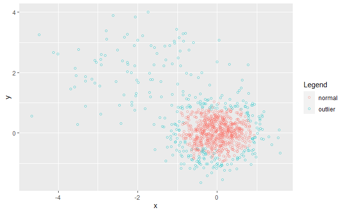

```r
ggplot(data, aes(x = Var1, y = Var2, color = outlier)) +
  geom_point(shape = 1, alpha = 0.5) +
  labs(x = "x", y = "y") +
  labs(alpha = "", colour="Legend")
```

### **ETAP 2** Sprawdzenie wpływu poszczególnych parametrów na jakość uzyskiwanej izolacji wartości odstających

**run_implemented_isolation_forest** - funkcja uruchumająca zaimplementowany algorytm Isolation Forest

Parametry:

- *sub_set_size* - liczba podzbiorza danych używanych dla tworzenia pojedycznego drzewa
- *num_of_trees* - liczba tworzych drzew w lasu

```r
run_isolaton_forest <- function(split_df, sub_set_size=256, num_of_trees = 100) {
  iforest <- IsolationForest$new()
  fit <- iforest$fit(split_df$train_no_label, num_of_tree, sub_set_size)
  pred <- iforest$predict(split_df$train_no_label, sub_set_size, 0.5)

  return(pred)
}
```

**run_if_with_param** - uruchomienie oraz zbieranie metryk algorytmu zwracajaca danna informację:

- sensitivity, recall albo true positive rate (TPR)
- specificity albo true negative rate (TNR)
- precision albo positive predictive value (PPV)
- negative albo predictive value (NPV)

#### Sprawdzenie dla zbioru danych z pliku *arrhytmia*

```r
name_of_data <- "arrhytmia"
data_to_test <- arrhythmia_data_df

set_of_tree_nums <- list(10, 20, 40, 80, 140, 180, 250, 300)
result_metrics_num_of_tree <- metric_for_num_of_tree(name_of_data,
                                                     data_to_test,
                                                     set_of_tree_nums,
                                                     title="",
                                                     x_title="Liczba tworzonych drzew w isolation forest",
                                                     y_title="Procent [%]")
sub_sets_size_list <- prepare_sub_set_size_list(nrow(data_to_test))
result_metrics_sub_set_size <- metric_for_sub_set_size(name_of_data,
                                                       data_to_test,
                                                       sub_sets_size_list,
                                                       title="",
                                                       x_title="Liczba danych dla tworzenia jednego drzewa",
                                                       y_title="Procent [%]")
df_sub_set_and_tree_num_metrics <- run_all_combination(data_to_test, set_of_tree_nums, sub_sets_size_list)
```

Wykres po lewej stronie przedstawia wpływ wartości oznaczająca liczba tworzynych drzew w lasie izolaczynjnym na wyniki działania algorytmu. Jako wyniki podane dane z **confision matrix**.

Wykres po prawej przedstawia wpływ wartości oznaczająca liczba zbiora danych z którego tworzone poszczególne drzewa w lasie izolaczynjnym na wyniki działania algorytmu. Jako wyniki podane dane z *confision matrix*.

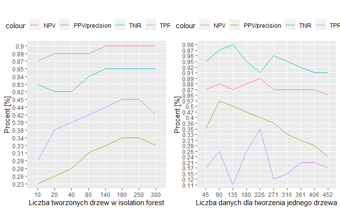

```r
grid.arrange(result_metrics_num_of_tree$plot, result_metrics_sub_set_size$plot, ncol = 2, widths=c(2,2))
```

Poszukiwanie najlepszej konfiguracji parametrów według **precision**:

```r
df_sub_set_and_tree_num_metrics$PPV[df_sub_set_and_tree_num_metrics$PPV == 'NaN'] <- 0
df_sub_set_and_tree_num_metrics_ppv <- df_sub_set_and_tree_num_metrics[order(df_sub_set_and_tree_num_metrics$PPV, decreasing = TRUE),]
df_show <- df_sub_set_and_tree_num_metrics_ppv[1:5, ]
df_show<- subset(df_show, select=c("sub_set_size", "num_of_trees", "PPV"))
knitr::kable(df_show, align = "lccrr")
```

|  | sub_set_size | num_of_trees | PPV |
| --- | --- | --- | --- |
| 13 | 20 | 135 | 1 |
| 22 | 40 | 90 | 0.86 |
| 11 | 20 | 45 | 0.8 |
| 23 | 40 | 135 | 0.75 |
| 41 | 140 | 45 | 0.68 |

Poszukiwanie najlepszej konfiguracji parametrów według **recall**:

```r
df_sub_set_and_tree_num_metrics_tpr <- df_sub_set_and_tree_num_metrics[order(df_sub_set_and_tree_num_metrics$TPR, decreasing = TRUE),]
df_show <- df_sub_set_and_tree_num_metrics_tpr[1:5, ]
df_show <- subset(df_show, select=c("sub_set_size", "num_of_trees", "TPR"))
knitr::kable(df_show, align = "lccrr")
```

|  | sub_set_size | num_of_trees | TPR |
| --- | --- | --- | --- |
| 65 | 250 | 226 | 0.44 |
| 68 | 250 | 361 | 0.44 |
| 69 | 250 | 406 | 0.44 |
| 70 | 250 | 452 | 0.44 |
| 62 | 250 | 90 | 0.42 |

#### Sprawdzenie dla zbioru danych z pliku *creditcard_data_df.csv*

nie udało się ze względu małej liczby mocy obliczeniowej lokalnej maszyny

Poszukiwanie najlepszej konfiguracji parametrów według **precision**:

[output not shown]

Poszukiwanie najlepszej konfiguracji parametrów według **recall**:

[output not shown]

### **ETAP 3** Badanie działania algorytmu z innymi dostępnymi w języku R metodami detekcji wartości odstających, takich jak:

1. K najbliższych sąsiadów (angl.*k-nearest neighbors*)
2. Klasyfikacja jednoklasowa (angl. *One-class SVM*)
3. Lokalny współczynnik wyjątkowości (angl. *Local outlier factor*)
4. Las losowy (angl. *Random Forests*)

#### 1. K najbliższych sąsiadów

```r
run_knn <- function(split_df, k=10) {
  # Stara implementacja
  #train <- split_df$train
  #test <- split_df$test
  #return(knn(train=split_df$train_no_label, test=split_df$test_no_label, cl=split_df$train_label, k=k))

  md <- CoreModel(label ~ ., split_df$train, model="knn")

  outliers<- rfOutliers(md, split_df$train)
  pred_df <- data.frame(pred=abs(outliers))
  pred_df$pred[pred_df$pred <  2] <- 0
  pred_df$pred[pred_df$pred >= 2] <- 1

  return(pred_df$pred)
}
```

#### 2. Klasyfikacja jednoklasowa

```r
run_one_class_svm <- function(split_df) {

  # training
  model <- svm(x=split_df$train_no_label, y=split_df$trainlabel, type='one-classification',kernel='linear')
  pred <- predict(model, split_df$test_no_label)

  # prepare result
  pred_df <- data.frame(pred)
  pred_df$pred[pred_df$pred== "TRUE"] <- 1
  pred_df$pred[pred_df$pred== "FALSE"] <- 0

  return(pred_df$pred)
}
```

#### 3. Lokalny współczynnik wyjątkowości

```r
run_lof <- function(split_df, kth_distance=10, threshold=0.9) {
  mlof = lof(split_df$train, k=kth_distance)
  thr = quantile(mlof, threshold)

  pred_df <- data.frame(pred=mlof)
  pred_df$pred[pred_df$pred < thr] <- 0
  pred_df$pred[pred_df$pred >= thr] <- 1

  return(pred_df$pred)
}
```

#### 4. Las losowy

Specyfikacji odnośnie funkcji randomForest [Link Random Forest](https://www.rdocumentation.org/packages/randomForest/versions/4.6-14/topics/randomForest)

```r
run_random_forest <- function(split_df) {

  md <- CoreModel(label ~ ., split_df$train, model="rf", rfNoTrees=30,
                maxThreads=1)

  outliers<- rfOutliers(md, split_df$train)
  pred_df <- data.frame(pred=abs(outliers))
  pred_df$pred[pred_df$pred <  2] <- 0
  pred_df$pred[pred_df$pred >= 2] <- 1

  return(pred_df$pred)
}
```

*run_algorithm_and_print_result* - funkcja uruchamiająca wybrany algorytm o wybranych parametrach:

1. *data_df* - dane wejściowe
2. *name_of_algo* - algorytm który ma zadziałać
3. *split_factor* - procent danych uczących się

```r
KNN_algo = "KNN"
ONE_SVM_algo = "One-SVM"
LOF_algo = "LOF"
RF_algo = "Random Forest"
IF_algo = "Isolation Forest"

run_algorithm_and_print_result <- function(data_df, test_data_name, name_of_algo, split_factor=1) {
  start.time <- Sys.time()
  split_train_test_df <- split_data_to_train_and_test(data_df, split_factor)

  expected = factor(split_train_test_df$train_label)
  pred = switch(
    name_of_algo,
    "KNN" = factor(run_knn(split_train_test_df)),
    "One-SVM"=factor(run_one_class_svm(split_train_test_df)),
    "LOF"=factor(run_random_forest(split_train_test_df)),
    "Random Forest"=factor(run_random_forest(split_train_test_df)),
    "Isolation Forest"=factor(run_isolation_forest(split_train_test_df))
   )
  end.time <- Sys.time()
  time.taken <- round(end.time - start.time, 4)
  result_eval = run_evaluation_metrics(pred, expected)

  TPR <- round(result_eval$conf$byClass[[1]], 2)
  TNR <- round(result_eval$conf$byClass[[2]], 2)
  PPV <- round(result_eval$conf$byClass[[3]], 2)
  NPV <- round(result_eval$conf$byClass[[4]], 2)

  return(c(test_data_name, name_of_algo, time.taken, TPR, TNR, PPV, NPV))
}
```

Porównanie algorytmów z innymi dla zbioru danych arrhytmia

```r
df_compare_algorithm
```

|  | test_data_name | algo | execution_time | TPR/recall | TNR | PPV/precision | NPV |
| --- | --- | --- | --- | --- | --- | --- | --- |
| 1 | arrhytmia | Random Forest | 4.1189 | 0.55 | 0.06 | 0.09 | 0.45 |
| 2 | arrhytmia | LOF | 3.7774 | 0.55 | 0.06 | 0.09 | 0.45 |
| 3 | arrhytmia | Isolation Forest | 0.8031 | 1 | 0 | 0.15 | NaN |

### **ETAP 4** Wnioski

Szybkość działania:

Nie udało się porównać wyników dla dużych zbiorów danych (credit_card) ze względu na ograniczenia mocy obliczeniowej komputerów którymi dysponujemy. A wybór podzbioru ze zbioru który dysponuje ekstremalnie małą liczbą wartości odstających często kończył się wyborem takiego podzbioru w którym nie było żadnych wartości odstających.

Implementacja zaproponowana przez nas znajduje się w pliku src/IsolationForest.R. Algorytm został zaimplementowany z użyciem biblioteki R6 która umożliwia implementacje klas w stylu języków obiektowych. Inną biblioteką zastosowaną jest data i jej modół tree który w prosty sposób pozwala tworzyć drzewa binarne.